# R per l’analisi statistica multivariata

Statistica descrittiva

## Importazione dei dati

Carichiamo nuovamente in memoria i dati `dde`, che sono stati considerati in precedenza.

```r
rm(list = ls()) # Rimozione di quanto presente nel workspace
path <- "https://tommasorigon.github.io/introR/data/dde.csv"
dde <- read.table(path, header = TRUE) # Scarica il file da internet

str(dde)
'data.frame':   2312 obs. of  2 variables:
 $ DDE: num  24.6 15.6 54.8 15 33.5 ...
 $ GAD: num  292 289 252 285 281 ...
```

## Nascite premature e non premature

- Il DDT è estremamente efficace contro le zanzare da malaria ed è pertanto largamente usato in zone in cui la malaria è endemica.
- Al tempo stesso, il DDT potrebbe costituire un rischio per la salute, specialmente nel caso di donne in gravidanza.
- Per un campione di $2312$ donne in gravidanza, viene misurato il DDE, ovvero una sostanza connessa al DDT, presente nel siero materno durante il terzo trimestre della gravidanza.
- Osserviamo inoltre che $361$ donne hanno partorito prematuramente, ovvero prima della conclusione della 37a settimana.

Dividiamo la variabile `DDE` in due gruppi. Il primo gruppo (variabile `dde_preterm`) fa riferimento ai parti prematuri mentre il secondo (variabile `dde_non_preterm`) considera i parti non prematuri.

```r
dde_preterm <- dde$DDE[dde$GAD < 37 * 7] # Gruppo parto prematuro
dde_non_preterm <- dde$DDE[dde$GAD >= 37 * 7] # Gruppo parto non prematuro

# Numerosità campionarie
length(dde_preterm)
[1] 361
length(dde_non_preterm)
[1] 1951
```

Rappresentiamo quindi gli istogrammi delle due variabili appena create.

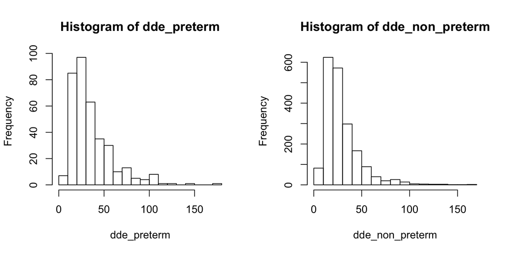

```r
par(mfrow = c(1, 2)) # Divide il grafico in due pannelli
hist(dde_preterm, breaks = 15)
hist(dde_non_preterm, breaks = 15)
```

## Media

Siamo interessati a trovare le medie aritmetiche delle variabili `dde_preterm` e `dde_non_preterm`. Possiamo ottenere questo risultato con i comandi seguenti.

```r
mean(dde_preterm) # Media aritmetica di DDE per donne con parto prematuro
[1] 36.20299
mean(dde_non_preterm) # Media aritmetica di DDE per donne con parto regolare
[1] 29.14199
```

Notiamo quindi che il DDE è presente in quantità maggiore tra le donne che hanno partorito prematuramente.La media aritmetica di una variabile numerica `x` si può anche ottenere come segue

```r
x <- c(10, 20, 25, 3.5, 28, 62) # Vettore di esempio

n <- length(x) # Numerosità campionaria
sum(x) / n # Media aritmetica di x
[1] 24.75
mean(x) # Media aritmetica di x
[1] 24.75
```

## Mediana

La mediana (Me) di una variabile è il valore *centrale* della distribuzione, ovvero:

$$\text{Me} = \begin{cases}x_{\left(\frac{n+1}{2}\right)}, &\qquad \text{ se } n \text{ è dispari}, \\[10pt] \left(x_{(n/2)} + x_{(n/2+1)}\right)/2,&\qquad \text{ se } n \text{ è pari}.\end{cases}$$

La mediana delle distribuzioni `dde_preterm` e `dde_non_preterm` si ottengono come segue:

```r
median(dde_preterm) # Mediana di DDE per donne con parto prematuro
[1] 29.46
median(dde_non_preterm) # Mediana di DDE per donne con parto regolare
[1] 24.04
```

Anche la mediana conferma che la quantità di DDE sembra essere maggiore tra le donne che hanno partorito prematuramente. Si noti, tuttavia, che medie e mediane differiscono di molto.

La mediana di una variabile numerica `x`, quando $n$ è pari, si può anche ottenere come segue

```r
x <- c(10, 20, 25, 3.5, 28, 62)
n <- length(x) # Numerosità campionaria
n # Si noti che n = 6 è pari
[1] 6

x_sort <- sort(x) # Vettore ordinato dei valori di x
x_sort
[1]  3.5 10.0 20.0 25.0 28.0 62.0

pos_med_1 <- n / 2 # Elemento in posizione n/2
pos_med_2 <- n / 2 + 1 # Elemento in posizione n/2+1

(x_sort[pos_med_1] + x_sort[pos_med_2]) / 2 # Mediana di x
[1] 22.5
median(x)
[1] 22.5
```

## La funzione di ripartizione empirica

Siano $x_1,\dots,x_n$ una collezione di dati, allora la funzione di ripartizione empirica è definita come

$$F(x) = \frac{1}{n} \sum_{i=1}^n \mathbb{I}(x_i \le x).$$

Il calcolo della funzione di ripartizione empirica della variabile `dde_preterm` si ottiene tramite il comando

```r
ecdf(dde_preterm)
Empirical CDF
Call: ecdf(dde_preterm)
 x[1:348] =   3.17,   6.28,   6.34,  ..., 144.86, 178.06

# Definisco la funzione di ripartizione di DDE
F_preterm <- ecdf(dde_preterm)

F_preterm(40) # Calcola la funzione di ripartizione empirica in 40
[1] 0.6980609
sum(dde_preterm <= 40) / length(dde_preterm) # Calcola la funzione di ripartizione empirica in 40
[1] 0.6980609
```

Si noti anche che la funzione di ripartizione empirica, valutata nella mediana, è circa pari a `0.5`.

```r
F_preterm(median(dde_preterm))
[1] 0.501385
```

## Confronto delle funzioni di ripartizione

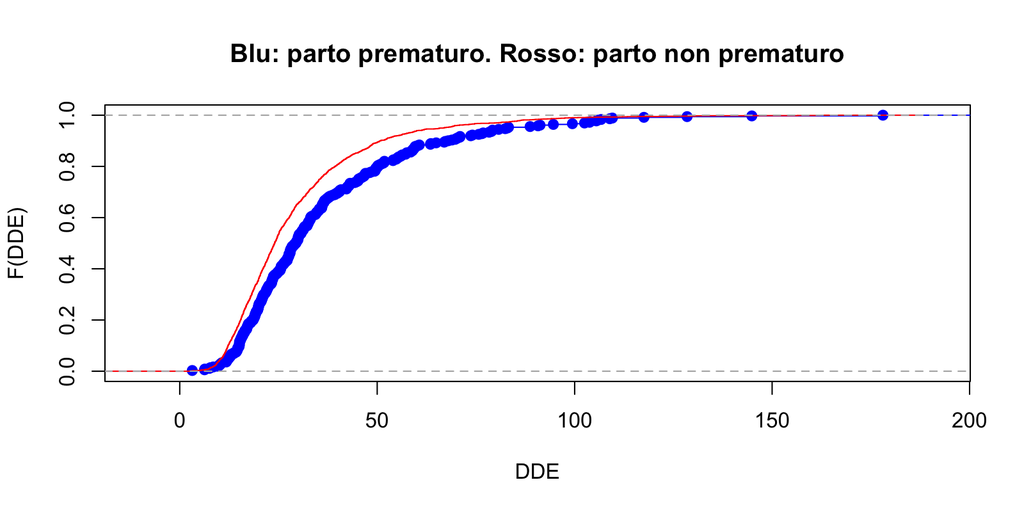

```r
plot(ecdf(dde_preterm),
  main = "Blu: parto prematuro. Rosso: parto non prematuro",
  xlab = "DDE",
  col = "blue",
  ylab = "F(DDE)"
)
lines(ecdf(dde_non_preterm), col = "red")
```

Si noti che la distribuzione di `dde_preterm` è spostata più a destra rispetto a quella di `dde_preterm`, ad ulteriore conferma che i valori di DDE sono maggior tra le donne che hanno partorito prematuramente.

## Quantili

Siano $x_1,\dots,x_n$ un insieme di dati, sia $p \in (0,1)$ e sia $F(x)$ la funzione di ripartizione empirica. Il quantile-$p$ è quindi pari a

$$\mathcal{Q}_p = \inf\{ x : F(x) \ge p \}.$$

Questa definizione di quantile si calcola in **R** come segue, per i valori $p = (0.1,0.25,0.75,0.9)$

```r
# Quantili di DDE (prematuro e non prematuro)
quantile(dde_preterm, probs = c(0.1, 0.25, 0.75, 0.9), type = 1)
  10%   25%   75%   90%
15.07 19.94 45.30 68.01
quantile(dde_non_preterm, probs = c(0.1, 0.25, 0.75, 0.9), type = 1)
  10%   25%   75%   90%
12.23 16.73 35.45 50.72
```

```r
# Primo quartile di DDE
min(dde_preterm[F_preterm(dde_preterm) >= 0.25])
[1] 19.94
# Terzo quartile di DDE
min(dde_preterm[F_preterm(dde_preterm) >= 0.75])
[1] 45.3
```

Si noti che la funzione di ripartizione calcolata nei quantili è circa pari ai valori $p$. Infatti:

```r
qq <- quantile(dde_preterm, probs = c(0.1, 0.25, 0.75, 0.9), type = 1)
F_preterm(qq)
[1] 0.1024931 0.2520776 0.7506925 0.9002770
```

## Ambiguità nel calcolo dei quantili

Differenti software e libri di testo usano diverse convenzioni per la definizione dei quantili. Per esempio, non necessariamente il secondo quartile e la mediana coincidono.

```r
x <- c(10, 2, 56, 28.8, 12, 26)
median(x)
[1] 19
quantile(x, probs = 0.5, type = 1)
50%
 12
```

In **R** esistono in totale 9 opzioni (si veda la documentazione `? quantile` per maggiori informazioni). Il default in **R** è la tipologia `type = 7`, che rende la mediana pari al secondo quartile.

```r
median(x)
[1] 19
quantile(x, probs = 0.5) # Ovvero: quantile(x, probs = 0.5, type = 7)
50%
 19
```

Per numerosità campionarie elevate le differenze tendono ad essere trascurabili. Elenchiamo qui di seguito alcuni esempi

```r
library(knitr) # Carica in memoria il pacchetto knitr

tab <- rbind(
  quantile(dde_preterm, probs = c(0.1, 0.25, 0.5, 0.75, 0.9), type = 1),
  quantile(dde_preterm, probs = c(0.1, 0.25, 0.5, 0.75, 0.9), type = 6),
  quantile(dde_preterm, probs = c(0.1, 0.25, 0.5, 0.75, 0.9), type = 7)
)
rownames(tab) <- c(1, 6, 7)
kable(tab, row.names = TRUE)
```

|  | 10% | 25% | 50% | 75% | 90% |
| --- | --- | --- | --- | --- | --- |
| 1 | 15.070 | 19.94 | 29.46 | 45.30 | 68.010 |
| 6 | 15.054 | 19.94 | 29.46 | 45.49 | 68.738 |
| 7 | 15.070 | 19.94 | 29.46 | 45.30 | 68.010 |

## La funzione `summary`

Per ottenere contemporaneamente le principali statistiche descrittive di una distribuzione (minimo, massimo, media, mediana e quartili), si usa spesso il comando seguente

```r
summary(dde_preterm)
   Min. 1st Qu.  Median    Mean 3rd Qu.    Max.
   3.17   19.94   29.46   36.20   45.30  178.06
summary(dde_non_preterm)
   Min. 1st Qu.  Median    Mean 3rd Qu.    Max.
   2.50   16.73   24.04   29.14   35.40  162.29
```

## I dati `emoglobina`

- Siamo interessati a confrontare l’efficacia di due diverse metodologie, chiamate A e B, per la misurazione dell’emoglobina nel sangue.
- Si è creato in laboratorio del sangue artificiale contenente 15 grammi di emoglobina ogni $100 \text{cm}^3$.

Dal composito sono stati estratti in totale $n = 360$ campioni.

Di questi, in $n_A = 180$ campioni l’emoglobina è stata misurata utilizzando la metodologia A mentre per i restanti $n_B = 180$ campioni è stata usata la metodologia B.

Alcuni dati sono riportati nella prossima slide. Le differenze tra le diverse misurazioni sono da attribuire in larga parte agli errori di misura delle due diverse metodologie.

```r
path <- "https://tommasorigon.github.io/introR/data/emoglobina.csv"
emoglobina <- read.table(path, header = TRUE, sep = ",", stringsAsFactors = TRUE) # Scarica il file da internet
```

```r
str(emoglobina)
'data.frame':   360 obs. of  2 variables:
 $ emoglobina : num  15 15.1 15.2 14.8 15 ...
 $ Metodologia: Factor w/ 2 levels "A","B": 1 1 1 1 1 1 1 1 1 1 ...

emo_A <- emoglobina$emoglobina[emoglobina$Metodologia == "A"] # Emoglobina gruppo A
emo_B <- emoglobina$emoglobina[emoglobina$Metodologia == "B"] # Emoglobina gruppo B

summary(emo_A)
   Min. 1st Qu.  Median    Mean 3rd Qu.    Max.
  14.44   14.87   15.00   15.00   15.14   15.64
summary(emo_B)
   Min. 1st Qu.  Median    Mean 3rd Qu.    Max.
  13.83   14.83   15.02   15.02   15.22   15.80
```

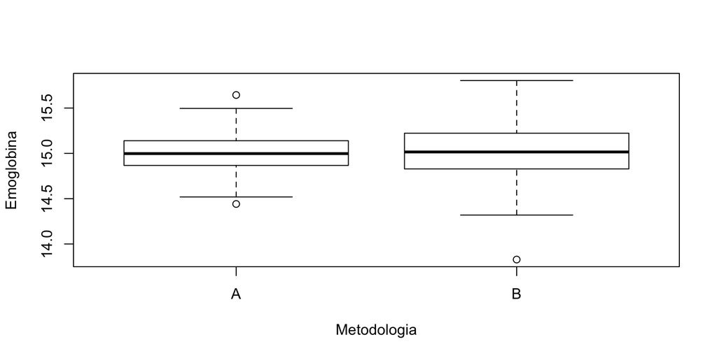

```r
par(mfrow = c(1, 1))
boxplot(emoglobina$emoglobina ~ emoglobina$Metodologia,
  ylab = "Emoglobina",
  xlab = "Metodologia"
)
```

## Varianza

La varianza dei dati $x_1,\dots,x_n$ è

$$\sigma^2 = \frac{(x_1 - \bar{x})^2 + (x_2 - \bar{x})^2 + \cdots + (x_n - \bar{x})^2}{n} = \frac{1}{n}\sum_{i=1}^n (x_i - \bar{x})^2.$$

La varianza delle variabili `emo_A` ed `emo_B` si calcola quindi come segue

```r
mean((emo_A - mean(emo_A))^2)
[1] 0.0456162
mean((emo_B - mean(emo_B))^2)
[1] 0.09901038
```

Si noti che la variabilità del gruppo $B$ è molto maggiore di quella del gruppo $A$. Lo stesso risultato si ottiene tramite la definizione alternativa

```r
mean(emo_A^2) - mean(emo_A)^2
[1] 0.0456162
mean(emo_B^2) - mean(emo_B)^2
[1] 0.09901038
```

Per poter fare confronti in futuro, definiamo la funzione della varianza

```r
my_var <- function(x) {
  mean(x^2) - mean(x)^2
}

my_var(emo_A)
[1] 0.0456162
my_var(emo_B)
[1] 0.09901038
```

La funzione `var` di **R** invece calcola

$$\frac{n}{n-1}\sigma^2 = \frac{1}{n-1}\sum_{i=1}^n (x_i - \bar{x})^2,$$
ovvero lo stimatore corretto della varianza quando i dati provendono da una distribuzione Gaussiana.

```r
var(emo_A)
[1] 0.04587104
var(emo_B)
[1] 0.09956351
```

## Scarto quadratico medio

Lo scarto quadratico medio si calcola considerando la radice quadrata della varianza. Esso è pari a

$$\text{sqm}(x) = \sigma = \sqrt{\sigma^2}.$$

Creiamo quindi una funzione opportuna per il suo calcolo.

```r
my_sd <- function(x) {
  sqrt(my_var(x))
}
```

```r
my_sd(emo_A)
[1] 0.2135795
my_sd(emo_B)
[1] 0.3146591
```

Anche in questo caso, si faccia attenzione che il comando `sd` di **R** invece calcola il valore di

$$\sqrt{\frac{1}{n-1}\sum_{i=1}^n (x_i - \bar{x})^2}.$$

```r
sd(emo_A)
[1] 0.2141753
sd(emo_B)
[1] 0.3155369

# Equivalente a
sqrt(var(emo_A))
[1] 0.2141753
sqrt(var(emo_B))
[1] 0.3155369
```

## Campo di variazione

Il campo di variazione è la differenza tra minimo e massimo della distribuzione, ovvero
$$(\text{Campo di variazione}) = x_{(n)} - x_{(1)}.$$

```r
max(emo_A) - min(emo_A)
[1] 1.20242
max(emo_B) - min(emo_B)
[1] 1.97508

# Comando alternativo
diff(range(emo_A))
[1] 1.20242
diff(range(emo_B))
[1] 1.97508
```

## Scarto interquartile

È la differenza tra il terzo ed il primo quartile, ovvero
$$(\text{Scarto interquartile}) = \mathcal{Q}_{0.75} - \mathcal{Q}_{0.25}.$$
È molto più **resistente** della varianza in presenza di poche osservazioni estreme. È usato soprattutto nelle situazioni in cui si sospetta la presenza di osservazioni anomale.

```r
diff(quantile(emo_A, probs = c(0.25, 0.75))) # Scarto interquartile gruppo A
      75%
0.2699275
diff(quantile(emo_B, probs = c(0.25, 0.75))) # Scarto interquartile gruppo B
      75%
0.3929925
```

## MAD

L’indice di variabilità MAD (Median absolute deviations) è definito come segue

$$\text{MAD} = \text{Mediana}(|x_1 - \text{Me}_x|, \dots, |x_n - \text{Me}_x|), \qquad \text{Me}_x = \text{Mediana}(x_1,\dots,x_n).$$

Per il suo calcolo, creiamo una funzione appropriata:

```r
MAD <- function(x) {
  median(abs(x - median(x)))
}
```

Il MAD della variabili `emo_A` ed `emo_B` sono quindi pari a

```r
MAD(emo_A)
[1] 0.135795
MAD(emo_B)
[1] 0.198025
```

Anche quest’ultimo indice mostra che il gruppo B è caratterizzato da maggiore variabilità.

## Indice di asimmetria di Pearson

Carichiamo in memoria i dati standardizzati presenti nel file `asimmetria.csv`.

```r
path <- "https://tommasorigon.github.io/introR/data/asimmetria.csv"
data_asym <- read.table(path, header = TRUE) # Scarica il file da internet
```

```r
str(data_asym)
'data.frame':   3000 obs. of  2 variables:
 $ x1: num  -0.5772 -0.2446 1.5563 0.0581 0.1172 ...
 $ x2: num  -0.1971 0.2536 -0.4169 -1.2463 0.0924 ...

x1 <- data_asym$x1
x2 <- data_asym$x2

summary(x1)
    Min.  1st Qu.   Median     Mean  3rd Qu.     Max.
-3.08125 -0.66797 -0.01697  0.00000  0.67522  3.43117
summary(x2)
   Min. 1st Qu.  Median    Mean 3rd Qu.    Max.
-1.7639 -0.7893 -0.1792  0.0000  0.5893  4.9458
```

Sebbene i dati siano standardizzati, notiamo delle differenze nella forma dovute alla asimmetria.

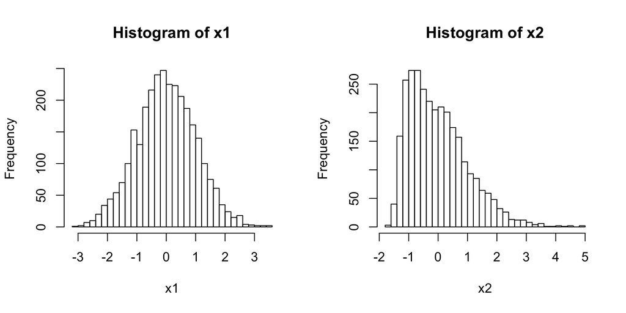

```r
par(mfrow = c(1, 2))
hist(x1, breaks = 30)
hist(x2, breaks = 30)
```

La misura di asimmetria di uso più comune è il cosiddetto indice di asimmetria standardizzato di Pearson, definito come
$$\gamma = \frac{1}{\text{sqm}(x)^3} \frac{1}{n} \sum_{i=1}^n (x_i - \bar{x})^3 = \frac{1}{n} \sum_{i=1}^n \left(\frac{x_i - \bar{x}}{\sigma}\right)^3.$$
Creiamo quindi una funzione opportuna per il suo calcolo.

```r
Pearson_sym <- function(x) {
  mean((x - mean(x))^3) / my_sd(x)^3
}
```

Tale indice è pari a zero se la distribuzione è simmetrica. Nel caso delle distribuzioni `x1`e `x2` otteniamo che

```r
Pearson_sym(x1)
[1] 0.03424704
Pearson_sym(x2)
[1] 0.9487522
```

L’indice pertanto evidenza una marcata asimmetria positiva nella distribuzione `x2`.

## Indice di curtosi di Pearson

```r
path <- "https://tommasorigon.github.io/introR/data/curtosi.csv"
data_kurt <- read.table(path, header = TRUE) # Scarica il file da internet
```

```r
str(data_kurt)
'data.frame':   3000 obs. of  3 variables:
 $ x1: num  -0.5772 -0.2446 1.5563 0.0581 0.1172 ...
 $ x2: num  -0.350346 -0.102829 1.543548 0.000571 0.022799 ...
 $ x3: num  -0.193 -0.421 -1.552 -0.867 1.96 ...

x1 <- data_kurt$x1
x2 <- data_kurt$x2
x3 <- data_kurt$x3

summary(x1)
    Min.  1st Qu.   Median     Mean  3rd Qu.     Max.
-3.08125 -0.66797 -0.01697  0.00000  0.67522  3.43117
summary(x2)
    Min.  1st Qu.   Median     Mean  3rd Qu.     Max.
-4.27436 -0.43463 -0.01462  0.00000  0.43802  5.05150
summary(x3)
     Min.   1st Qu.    Median      Mean   3rd Qu.      Max.
-1.991031 -0.797102 -0.003507  0.000000  0.801576  2.007715
```

Sebbene i dati siano standardizzati, notiamo delle differenze nella forma. Si noti inoltre che le distribuzioni sono sostanzialmente simmetriche.

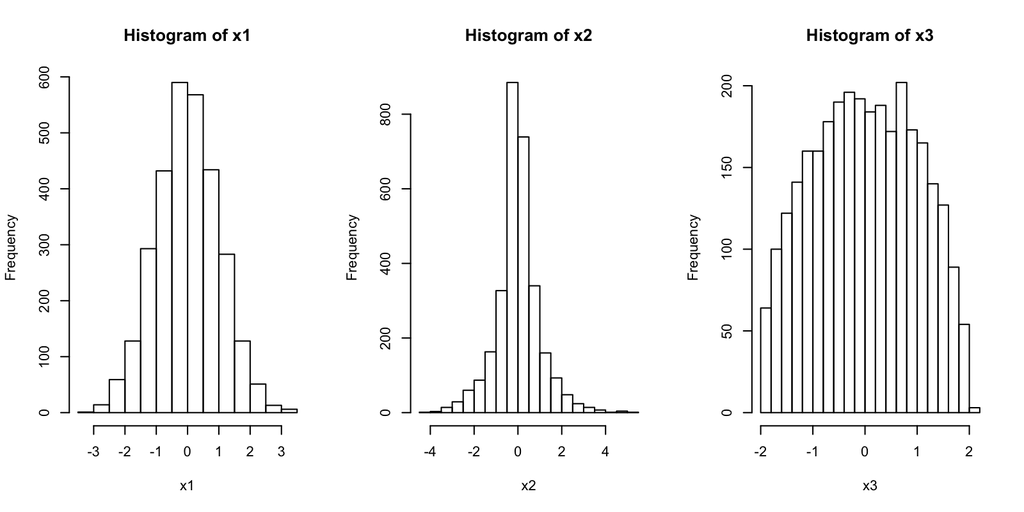

```r
par(mfrow = c(1, 3))
hist(x1, breaks = 20)
hist(x2, breaks = 20)
hist(x3, breaks = 20)
```

```r
Pearson_sym(x1)
[1] 0.03424704
Pearson_sym(x2)
[1] 0.162238
Pearson_sym(x3)
[1] -0.01713243
```

La seconda distribuzione ha delle code più “pesanti” ed è più appuntita della prima. Viceversa, la terza distribuzione ha le code più leggere ed è meno appuntita della prima.

La misura di curtosi di uso più comune è il cosiddetto indice di curtosi standardizzato di Pearson, definito come
$$\kappa = \frac{1}{\text{sqm}(x)^4} \frac{1}{n} \sum_{i=1}^n (x_i - \bar{x})^4 = \frac{1}{n} \sum_{i=1}^n \left(\frac{x_i - \bar{x}}{\sigma}\right)^4.$$

Creiamo quindi una funzione opportuna per il suo calcolo.

```r
Pearson_kurt <- function(x) {
  mean((x - mean(x))^4) / my_sd(x)^4
}
```

Tale indice è pari a 3 se i dati provengono da una distribuzione Gaussiana. Nel caso delle distribuzioni `x1`, `x2` ed `x3` otteniamo che

```r
Pearson_kurt(x1)
[1] 2.960931
Pearson_kurt(x2)
[1] 5.520026
Pearson_kurt(x3)
[1] 2.011334
```

## Covarianza

Consideriamo il dataset `cars` disponibile nella libreria **R**. È possibile caricarlo in memoria usando il comando

```r
data(cars)
str(cars)
'data.frame':   50 obs. of  2 variables:
 $ speed: num  4 4 7 7 8 9 10 10 10 11 ...
 $ dist : num  2 10 4 22 16 10 18 26 34 17 ...
```

La documentazione ufficiale (ovvero `? cars`) descrive il contenuto di questo dataset.

```
The data give the speed of cars and the distances taken to stop. Note that the data were recorded in the 1920s.

[,1]    speed   numeric Speed (mph)
[,2]    dist    numeric Stopping distance (ft)
```

Siamo quindi interessati a quantificare la relazione tra la variabile `speed` e la variabile `dist`. Anzitutto, ne facciamo un grafico

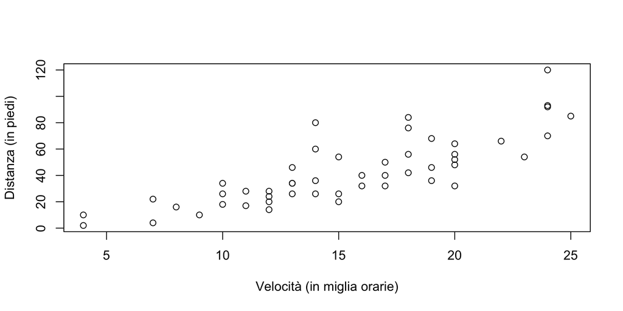

```r
par(mfrow = c(1, 1))
plot(cars$speed, cars$dist, xlab = "Velocità (in miglia orarie)", ylab = "Distanza (in piedi)")
```

L’indicatore più diffuso è la covarianza tra due insiemi di dati $x_1,\dots,x_n$ e $y_1,\dots,y_n$, definita come

$$\text{cov}(x,y) = \frac{1}{n}\sum_{i=1}^n(x_i - \bar{x})(y_i - \bar{y}).$$
La covarianza delle variabili `speed` e `dist` si calcola quindi come segue

```r
mean((cars$speed - mean(cars$speed)) * (cars$dist - mean(cars$dist)))
[1] 107.748
```

Si noti che la covarianza è positiva, come si poteva intuire dal grafico. Lo stesso risultato si ottiene tramite la definizione alternativa

```r
mean(cars$speed * cars$dist) - mean(cars$speed) * mean(cars$dist)
[1] 107.748
```

Scriviamo anche in questo caso la funzione appropriata

```r
my_cov <- function(x, y) {
  mean((x - mean(x)) * (y - mean(y)))
}

# Si noti che la funzione è simmetrica
my_cov(cars$speed, cars$dist)
[1] 107.748
my_cov(cars$dist, cars$speed)
[1] 107.748
```

In **R** si può usare la funzione `cov`, che però calcola una quantità leggermente diversa, ovvero

$$\frac{1}{n - 1}\sum_{i=1}^n(x_i - \bar{x})(y_i - \bar{y}).$$

```r
cov(cars$speed, cars$dist)
[1] 109.9469
```

## Correlazione

L’indice di correlazione è definito come

$$\rho = \frac{\text{cov}(x,y)}{\sqrt{\text{var}(x) \text{var}(y)}}.$$
Scriviamo anche in questo caso la funzione appropriata

```r
my_cor <- function(x, y) {
  my_cov(x, y) / sqrt(my_var(x) * my_var(y))
}
```

Si noti che in questo caso la funzione `cor` di **R** coincide con la nostra versione, poichè le rispettive costanti (ovvero $n$ ed $n-1$), si semplificano. Pertanto avremo che

```r
my_cor(cars$speed, cars$dist)
[1] 0.8068949
cor(cars$speed, cars$dist)
[1] 0.8068949
cov(cars$speed, cars$dist) / sqrt(var(cars$speed) * var(cars$dist))
[1] 0.8068949
```

L’indice di correlazione è positivo ed elevato: si evidenzia una forte relazione lineare positiva tra le due variabili.